### Warty sea cucumber by island (CINP data)

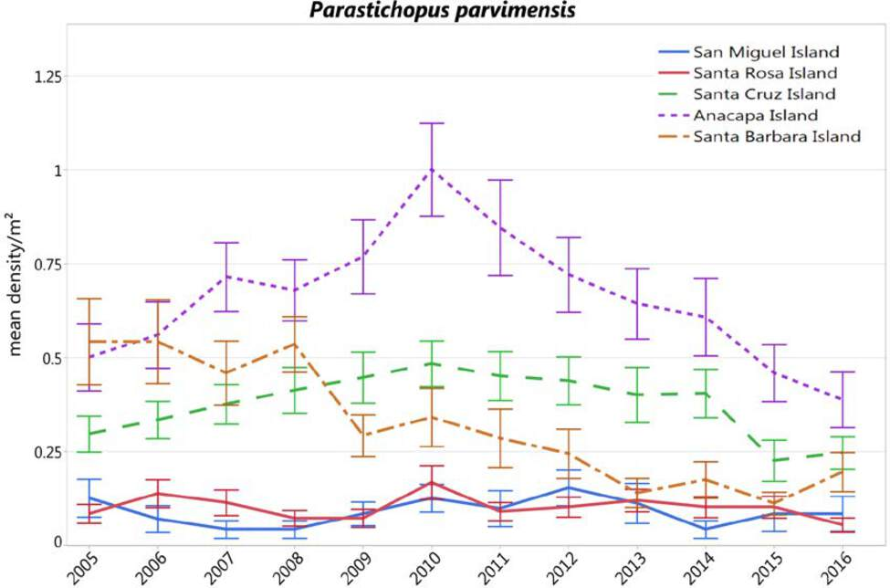

**Figure App.F.13.12.**. A figure showing the average density of warty sea cucumbers across the Northern Channel Islands from 2005 - 2016.

**Click for Details**

Figure App.F.13.12. Average density of warty sea cucumber *Parastichopus parvimensis* at Channel Islands National Park kelp forest monitoring sites at the five islands in Channel Islands National Marine Sanctuary. Densities are lower, but stable at San Miguel (blue) and Santa Rosa (red) islands, while densities have declined recently at the other islands. For this graph, sea cucumber density was averaged across all monitoring sites at each island, including sites located inside and outside of marine reserves and conservation areas, to examine course-scale trends by island. At a finer scale, sea cucumber density is responding differently inside and outside of some marine protected areas (MPAs) in CINMS. A discussion of MPA effects in CINMS is available in MPA Effects. Figure: [Channel Islands National Park](https://www.nps.gov/chis/index.htm)

### Sea cucumber island vs. mainland (SBC-LTER data)

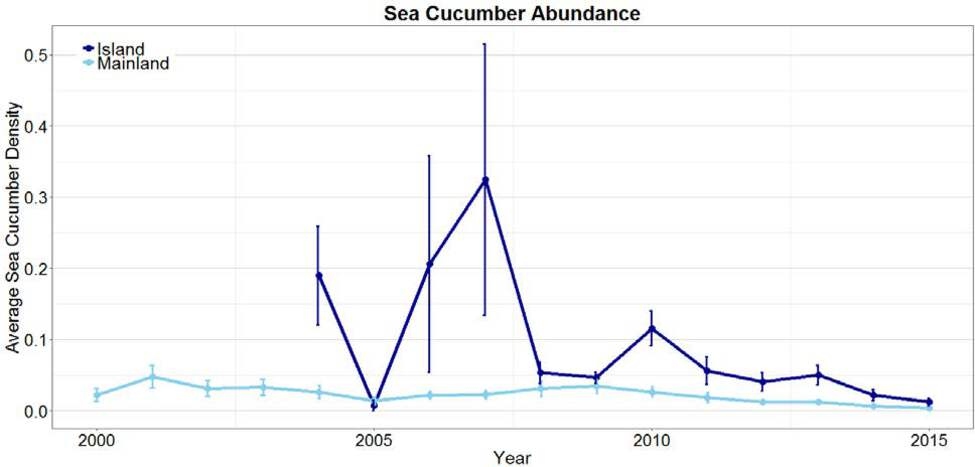

**Figure App.F.13.13.**. A figure showing a comparison of the average density of sea cucumbers from two of the Northern Channel Islands to mainland sites from 2000 - 2015.

**Click for Details**

Average density (+/- standard error) of sea cucumber (*Parastichopus spp.*) at 2 island (dark blue) and 9 mainland (light blue) kelp forest sites monitored by the Santa Barbara Channel Long-term Ecological Research (SBC LTER) program. Data source: SBC LTER; Figure: [R. Freedman/NOAA](https://channelislands.noaa.gov/contact/freedman.html)